# Lab 2: Cats vs Dogs

## Part 4. Hyperparameter Search [6 pt]

### Part (a) - 2pt

Based on the plots from above, choose another set of values for the hyperparameters (network, batch_size, learning_rate) that you think would help you improve the validation accuracy. Justify your choice.

```python
#The set of parameter I chose is:

#network: Large_net, because large_net has two filters,
#it can capture higher level features that distinguish
#cat and dog.

#bacth_size: 128, because 64 is still a little bit
#slow for large_net to train, and having a large batch
#size may prevent the model's focus on learning too much,
#which result in overfitting. Although a batch size
#of 512 is a good fit as we tested in part 3(c), it will
#result in a higher validation error and loss.

#learning_rate: 0.005, the 0.001 learning rate
#performed very well on the model in part 3, but
#consumed too much time on tunning the weights,
#so I decide to increase it.
```

### Part (b) - 1pt

Train the model with the hyperparameters you chose in part(a), and include the training curve.

```
Files already downloaded and verified
Files already downloaded and verified
Epoch 1: Train err: 0.466625, Train loss: 0.6925613236805749 |Validation err: 0.4305, Validation loss: 0.6916250362992287
Epoch 2: Train err: 0.45025, Train loss: 0.6910346017943488 |Validation err: 0.4295, Validation loss: 0.6889704614877701
Epoch 3: Train err: 0.4305, Train loss: 0.6885886050405956 |Validation err: 0.4165, Validation loss: 0.6850010603666306
Epoch 4: Train err: 0.430625, Train loss: 0.6850024423901997 |Validation err: 0.4125, Validation loss: 0.6797147057950497
Epoch 5: Train err: 0.420875, Train loss: 0.6813881851377941 |Validation err: 0.411, Validation loss: 0.6762721762061119
Epoch 6: Train err: 0.415875, Train loss: 0.6773001438095456 |Validation err: 0.4125, Validation loss: 0.672969501465559
Epoch 7: Train err: 0.405, Train loss: 0.6732292080682422 |Validation err: 0.4055, Validation loss: 0.6696001030504704
Epoch 8: Train err: 0.4, Train loss: 0.6694153556748043 |Validation err: 0.402, Validation loss: 0.6651207581162453
Epoch 9: Train err: 0.3905, Train loss: 0.6657110272891937 |Validation err: 0.3965, Validation loss: 0.6595559529960155
Epoch 10: Train err: 0.38475, Train loss: 0.6609666309659443 |Validation err: 0.398, Validation loss: 0.6561728976666927
Epoch 11: Train err: 0.374625, Train loss: 0.6547484369505019 |Validation err: 0.3895, Validation loss: 0.6526741832494736
Epoch 12: Train err: 0.379125, Train loss: 0.6503025397421822 |Validation err: 0.382, Validation loss: 0.644683513790369
Epoch 13: Train err: 0.3685, Train loss: 0.6430244833704025 |Validation err: 0.377, Validation loss: 0.6408736705780029
Epoch 14: Train err: 0.35375, Train loss: 0.634985539648268 |Validation err: 0.3715, Validation loss: 0.6393358670175076
Epoch 15: Train err: 0.35375, Train loss: 0.6319066002255395 |Validation err: 0.385, Validation loss: 0.6489016860723495
Epoch 16: Train err: 0.35125, Train loss: 0.6263072131172059 |Validation err: 0.357, Validation loss: 0.6286376938223839
Epoch 17: Train err: 0.349875, Train loss: 0.6246873547160436 |Validation err: 0.351, Validation loss: 0.6268594488501549
Epoch 18: Train err: 0.343, Train loss: 0.6182309228276449 |Validation err: 0.3415, Validation loss: 0.6208269745111465
Epoch 19: Train err: 0.33675, Train loss: 0.6112786872046334 |Validation err: 0.348, Validation loss: 0.6215575821697712
Epoch 20: Train err: 0.334875, Train loss: 0.6074399777821132 |Validation err: 0.3385, Validation loss: 0.6121908687055111
Epoch 21: Train err: 0.328375, Train loss: 0.603059540665339 |Validation err: 0.337, Validation loss: 0.6123869866132736
Epoch 22: Train err: 0.327375, Train loss: 0.5975976425503927 |Validation err: 0.333, Validation loss: 0.6109451837837696
Epoch 23: Train err: 0.322375, Train loss: 0.5930433736907111 |Validation err: 0.3245, Validation loss: 0.6026575490832329
Epoch 24: Train err: 0.317875, Train loss: 0.5886693076481895 |Validation err: 0.327, Validation loss: 0.5991024523973465
Epoch 25: Train err: 0.306375, Train loss: 0.5787286261717478 |Validation err: 0.315, Validation loss: 0.596717856824398
Epoch 26: Train err: 0.30725, Train loss: 0.572699801316337 |Validation err: 0.321, Validation loss: 0.5967751257121563
Epoch 27: Train err: 0.302875, Train loss: 0.5695816690013522 |Validation err: 0.3185, Validation loss: 0.5978134162724018
Epoch 28: Train err: 0.300875, Train loss: 0.5655642464047387 |Validation err: 0.334, Validation loss: 0.6142176277935505
Epoch 29: Train err: 0.294125, Train loss: 0.5602825222507356 |Validation err: 0.3275, Validation loss: 0.6087971664965153
Epoch 30: Train err: 0.291875, Train loss: 0.5594303224767957 |Validation err: 0.328, Validation loss: 0.6033484600484371
Finished Training
Total time elapsed: 150.55 seconds
```

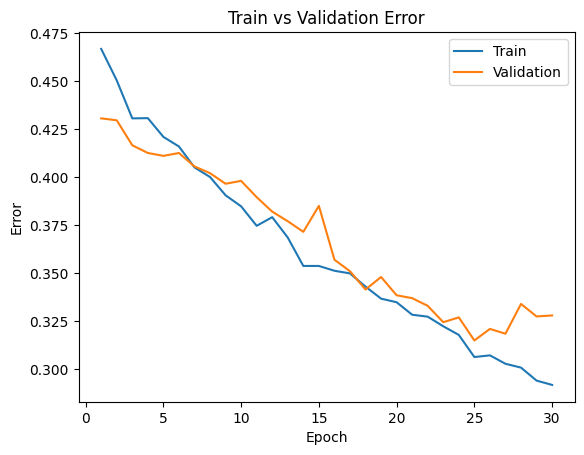

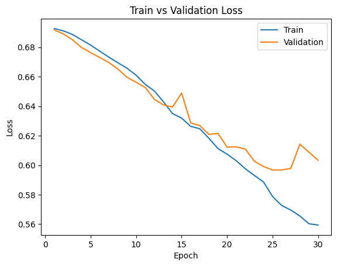

```python
large_net = LargeNet()
train_net(large_net, batch_size = 128, learning_rate = 0.005)
my_model_path = get_model_name("large", batch_size = 128,
                               learning_rate = 0.005, epoch = 29)
plot_training_curve(my_model_path)
```

### Part (c) - 2pt

Based on your result from Part(a), suggest another set of hyperparameter values to try. Justify your choice.

```python
#Another set of hyperparamter I would try is:

#network: Large_net, because large_net
#has two filters, it can capture
#higher level features that distinguish cat and dog.

#bacth_size: 128, staying the same, because
#it seems to be a good fit.

#learning_rate: 0.007, because the model seems to
#have similar training time as the default
#parameter. Thus, I would increase the learning
#rate to see if the time reduces.
```

### Part (d) - 1pt

Train the model with the hyperparameters you chose in part(c), and include the training curve.

```
Files already downloaded and verified
Files already downloaded and verified
Epoch 1: Train err: 0.486125, Train loss: 0.6929923277052622 |Validation err: 0.462, Validation loss: 0.691496804356575
Epoch 2: Train err: 0.447625, Train loss: 0.6898457143041823 |Validation err: 0.436, Validation loss: 0.6869067177176476
Epoch 3: Train err: 0.438, Train loss: 0.6855275839094132 |Validation err: 0.4305, Validation loss: 0.6815641149878502
Epoch 4: Train err: 0.424875, Train loss: 0.6788790330054268 |Validation err: 0.424, Validation loss: 0.6740341857075691
Epoch 5: Train err: 0.410625, Train loss: 0.6723156069952344 |Validation err: 0.4, Validation loss: 0.6672771535813808
Epoch 6: Train err: 0.399125, Train loss: 0.664779712283422 |Validation err: 0.402, Validation loss: 0.6627656742930412
Epoch 7: Train err: 0.3885, Train loss: 0.6593310568067763 |Validation err: 0.3915, Validation loss: 0.6555960960686207
Epoch 8: Train err: 0.382375, Train loss: 0.6516290004291232 |Validation err: 0.382, Validation loss: 0.6483094692230225
Epoch 9: Train err: 0.37025, Train loss: 0.6463586432593209 |Validation err: 0.37, Validation loss: 0.6411598920822144
Epoch 10: Train err: 0.368625, Train loss: 0.6428424933600048 |Validation err: 0.3705, Validation loss: 0.6401523053646088
Epoch 11: Train err: 0.357375, Train loss: 0.6348766939980643 |Validation err: 0.376, Validation loss: 0.6367527991533279
Epoch 12: Train err: 0.353625, Train loss: 0.6284563569795518 |Validation err: 0.36, Validation loss: 0.6303407028317451
Epoch 13: Train err: 0.350125, Train loss: 0.6261693390588912 |Validation err: 0.364, Validation loss: 0.6261237040162086
Epoch 14: Train err: 0.33875, Train loss: 0.6181833280457391 |Validation err: 0.372, Validation loss: 0.6287984065711498
Epoch 15: Train err: 0.339625, Train loss: 0.6148951734815326 |Validation err: 0.3525, Validation loss: 0.6365647688508034
Epoch 16: Train err: 0.33925, Train loss: 0.6088614454345097 |Validation err: 0.352, Validation loss: 0.6181153208017349
Epoch 17: Train err: 0.330625, Train loss: 0.6039005631492251 |Validation err: 0.3465, Validation loss: 0.6129559874534607
Epoch 18: Train err: 0.32525, Train loss: 0.5966078733641004 |Validation err: 0.341, Validation loss: 0.6029507741332054
Epoch 19: Train err: 0.320375, Train loss: 0.5881873416522193 |Validation err: 0.349, Validation loss: 0.6267595551908016
Epoch 20: Train err: 0.319375, Train loss: 0.5842690155619666 |Validation err: 0.331, Validation loss: 0.6079521216452122
Epoch 21: Train err: 0.314125, Train loss: 0.5813383024836344 |Validation err: 0.3335, Validation loss: 0.5973181687295437
Epoch 22: Train err: 0.304375, Train loss: 0.5732384598444379 |Validation err: 0.3195, Validation loss: 0.5890955664217472
Epoch 23: Train err: 0.303, Train loss: 0.5689865445333814 |Validation err: 0.325, Validation loss: 0.5860350355505943
Epoch 24: Train err: 0.300875, Train loss: 0.5666398836506737 |Validation err: 0.3195, Validation loss: 0.5924878232181072
Epoch 25: Train err: 0.291125, Train loss: 0.5538880432408954 |Validation err: 0.31, Validation loss: 0.5819087289273739
Epoch 26: Train err: 0.288375, Train loss: 0.5506627252177586 |Validation err: 0.313, Validation loss: 0.5807468295097351
Epoch 27: Train err: 0.280625, Train loss: 0.54737716865918 |Validation err: 0.3125, Validation loss: 0.5856056362390518
Epoch 28: Train err: 0.277875, Train loss: 0.5383775688353039 |Validation err: 0.308, Validation loss: 0.5820190422236919
Epoch 29: Train err: 0.275375, Train loss: 0.5328794949584537 |Validation err: 0.311, Validation loss: 0.584551926702261
Epoch 30: Train err: 0.269, Train loss: 0.5298422934517028 |Validation err: 0.309, Validation loss: 0.5883184187114239
Finished Training
Total time elapsed: 151.98 seconds
```

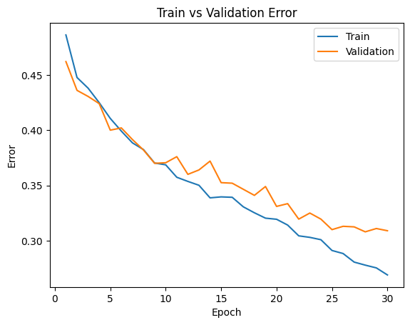

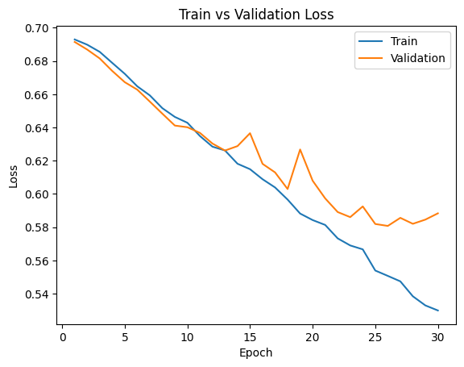

```python
large_net = LargeNet()
train_net(large_net, batch_size = 128, learning_rate = 0.007)
my_model_path2 = get_model_name("large", batch_size = 128,
                                learning_rate = 0.007, epoch = 29)
plot_training_curve(my_model_path2)
```